# Gramática de Gráficas (ggplot2)

Estudio R

Octubre de 2017

# Una mala gráfica

No tan buena…

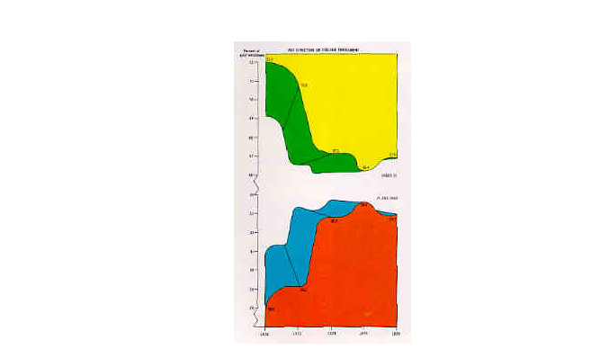

Otra opción:

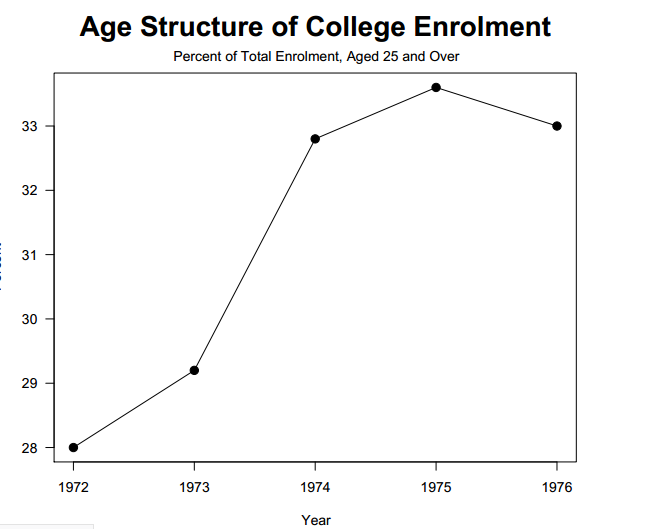

# Una muy buena gráfica

[figure not shown]

# Gramática de gráficas

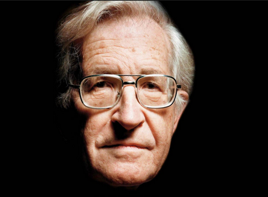

- Proporciona reglas al lenguaje
- Sistema formal de reglas
- Gramática de `Chomsky`
- No son necesariamente “gráficas bonitas”
- Basado en la gramática de las gráficas de `Wilkinson`
- `ggplot2` está diseñado para trabajar por capas

# Componentes de las gráficas de `ggplot2`

- Los datos (`data`)
- Mapeo estético (`aes`)
- Objetos geométricos (`geom`)
- Transformaciones estadísticas (`stat`)
- Escalas (`scale`)
- Sistema de coordenadas
- Posición

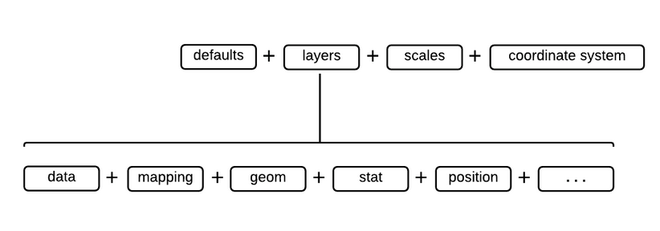

[Aquí](https://www.rstudio.com/wp-content/uploads/2015/04/ggplot2-spanish.pdf) hay una guía de `ggplot2` en R.

# Lectura de datos

```r
icfes17 <- read.csv(file = "ICFES_2017_01.csv", sep = "¬")
head(icfes17, n = 10)
```

```
##    ESTU_TIPODOCUMENTO ESTU_NACIONALIDAD ESTU_GENERO ESTU_FECHANACIMIENTO
## 1                  CR          COLOMBIA   Masculino           06/08/1998
## 2                  TI          COLOMBIA    Fenemino           29/12/2000
## 3                  TI          COLOMBIA   Masculino           22/12/1999
## 4                  TI          COLOMBIA   Masculino           15/01/1999
## 5                  TI          COLOMBIA   Masculino           14/10/1999
## 6                  CC          COLOMBIA    Fenemino           10/10/1998
## 7                  TI          COLOMBIA   Masculino           01/04/2000
## 8                  TI          COLOMBIA   Masculino           14/05/1999
## 9                  CC          COLOMBIA    Fenemino           17/09/1997
## 10                 TI          COLOMBIA    Fenemino           03/10/2000
##    PERIODO ESTU_CONSECUTIVO ESTU_ESTUDIANTE ESTU_TIENE_ETNIA ESTU_ETNIA
## 1    20171 SB11201710054752      ESTUDIANTE               NO
## 2    20171 SB11201710021698      ESTUDIANTE               NO
## 3    20171 SB11201710045732      ESTUDIANTE               NO
```

[output cut: 304 more lines]

# Editanto los datos

```r
icfes17 <- icfes17[, -c(5,6,7,12,14,39,43,46,48,50,52,54,55,58,74)]
head(icfes17)
```

```
##   ESTU_TIPODOCUMENTO ESTU_NACIONALIDAD ESTU_GENERO ESTU_FECHANACIMIENTO
## 1                 CR          COLOMBIA   Masculino           06/08/1998
## 2                 TI          COLOMBIA    Fenemino           29/12/2000
## 3                 TI          COLOMBIA   Masculino           22/12/1999
## 4                 TI          COLOMBIA   Masculino           15/01/1999
## 5                 TI          COLOMBIA   Masculino           14/10/1999
## 6                 CC          COLOMBIA    Fenemino           10/10/1998
##   ESTU_TIENE_ETNIA ESTU_ETNIA ESTU_PAIS_RESIDE ESTU_DEPTO_RESIDE
## 1               NO                    COLOMBIA            BOGOTA
## 2               NO                    COLOMBIA             VALLE
## 3               NO                    COLOMBIA             VALLE
## 4               NO                    COLOMBIA             VALLE
## 5               NO                    COLOMBIA             VALLE
## 6               NO                    COLOMBIA         ATLANTICO
##   ESTU_MCPIO_RESIDE ESTU_HORAS_SEMANATRABAJA
## 1       BOGOTÁ D.C.
## 2             YUMBO
## 3           PALMIRA
## 4              CALI
## 5              CALI
## 6      BARRANQUILLA
##                FAMI_EDUCACION_PADRE                FAMI_EDUCACION_MADRE
## 1                         No Aplica    Educación Profesional Incompleta
## 2    Educación Profesional Completa      Educación Profesional Completa
## 3               Primaria Incompleta Secundaria(Bachillerato) Incompleta
## 4
## 5 Secundaria(Bachillerato) Completa   Secundaria(Bachillerato) Completa
## 6
##   FAMI_ESTRATO_VIVIENDA FAMI_TIENE_INTERNET FAMI_TIENE_SERVICIOTV
## 1             Estrato 4                  SI                    SI
## 2             Estrato 3                  SI                    SI
## 3             Estrato 2                  SI                    SI
## 4             Estrato 4                  SI                    SI
## 5             Estrato 3                  SI                    SI
## 6
##   FAMI_TIENE_COMPUTADOR FAMI_TIENE_LAVADORA FAMI_TIENE_HORNO_MICROOGAS
## 1                    SI                  SI                         SI
## 2
## 3
## 4                    SI                  SI                         SI
```

[output cut: 113 more lines]

```
## 6                       58                          3
##   PERCENTIL_SOCIALES_CIUDADANAS ESTU_INSE_INDIVIDUAL ESTU_NSE_INDIVIDUAL
## 1                            13          67,18043322                NSE4
## 2                            45
## 3                            33
## 4                            15
## 5                            27          55,95287999                NSE3
## 6                            53
##   ESTU_NSE_ESTABLECIMIENTO
## 1                        3
## 2                        3
## 3                        3
## 4                        3
## 5                        3
## 6                        4
```

Renombrando variables:

```r
names(icfes17) <- c("TipoDocumento", "Nacionalidad", "Genero",
                    "FechaNac", "TieneEtnia", "Etnia", "PaisReside",
                    "DptoReside", "MpioReside", "HorasSemTrabaja",
                   "EducaPadre",
                    "EducaMadre", "Estrato", "Internet", "TV", "PC",
                    "Lavadora", "Horno", "Automovil", "Moto", "Consola",
                    "FliaLibros", "LecturaDia", "ComeLeche", "ComeCPH",
                    "ComeCFL", "TrabajoPadre", "TrabajoMadre",
                    "PersonasHog", "CuartosHog", "DedicacionInternet",
                    "E_Remunera", "FliaSituaEconomic", "Colegio",
                    "ColegioGenero", "ColNaturaleza", "Bilingue",
                    "ColCaracter", "NombreSede", "AreaUbica",
                    "MunicipioCol", "DeptoCol", "MpioPresent",
                    "DptoPresent", "MatematicasPu", "MatematicasDe",
                    "MatematicasPe", "InglesPu", "InglesDe", "InglesPe",
                    "CNaturalesPu", "CNaturalesDe", "CNaturalesPe",
                    "LecturaCriticaPu", "LecturaCriticaDe",
                    "LecturaCriticaPe", "SocialesPu", "SocialesDe",
                    "SocialesPe", "EstINSEtIndivi", "EstNSEIndivi",
                    "EstNSEEstablec")
head(icfes17)
```

```
##   TipoDocumento Nacionalidad    Genero   FechaNac TieneEtnia Etnia
## 1            CR     COLOMBIA Masculino 06/08/1998         NO
## 2            TI     COLOMBIA  Fenemino 29/12/2000         NO
## 3            TI     COLOMBIA Masculino 22/12/1999         NO
## 4            TI     COLOMBIA Masculino 15/01/1999         NO
## 5            TI     COLOMBIA Masculino 14/10/1999         NO
## 6            CC     COLOMBIA  Fenemino 10/10/1998         NO
##   PaisReside DptoReside   MpioReside HorasSemTrabaja
## 1   COLOMBIA     BOGOTA  BOGOTÁ D.C.
## 2   COLOMBIA      VALLE        YUMBO
## 3   COLOMBIA      VALLE      PALMIRA
## 4   COLOMBIA      VALLE         CALI
## 5   COLOMBIA      VALLE         CALI
## 6   COLOMBIA  ATLANTICO BARRANQUILLA
##                          EducaPadre                          EducaMadre
```

[output cut: 97 more lines]

# Gráficos a construir

- Diagramas de barras (`geom_bar`)
- Histogramas (`geom_histogram`)
- Densidad (`geom_density`)
- Boxplot (`geom_boxplot`)
- Diagrama de dispersión (`geom_point` o `geom_jitter`)

# Diagramas de barras (`geom_bar`)

Diagrama de barras por tipo de colegio, según clasficiación de género:

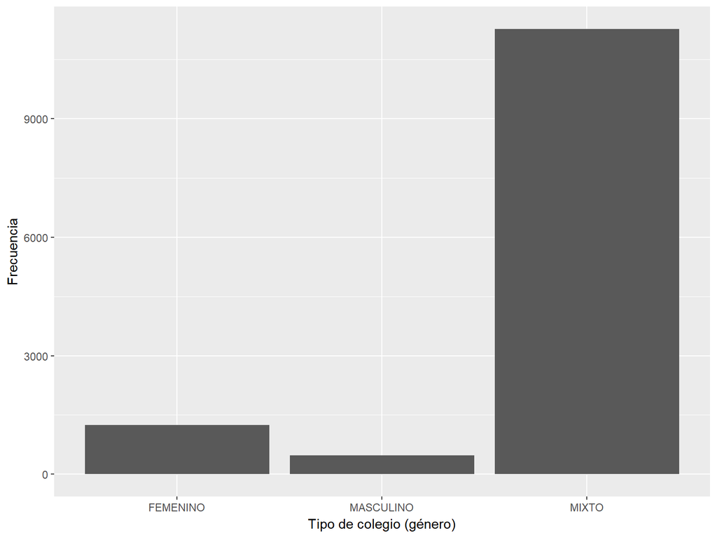

```r
library(ggplot2)
g <- ggplot(data = icfes17, aes(x = ColegioGenero))
g <- g + geom_bar()
g <- g + xlab("Tipo de colegio (género)") + ylab("Frecuencia")
g
```

Diagrama de barras para clasificación de ingles:

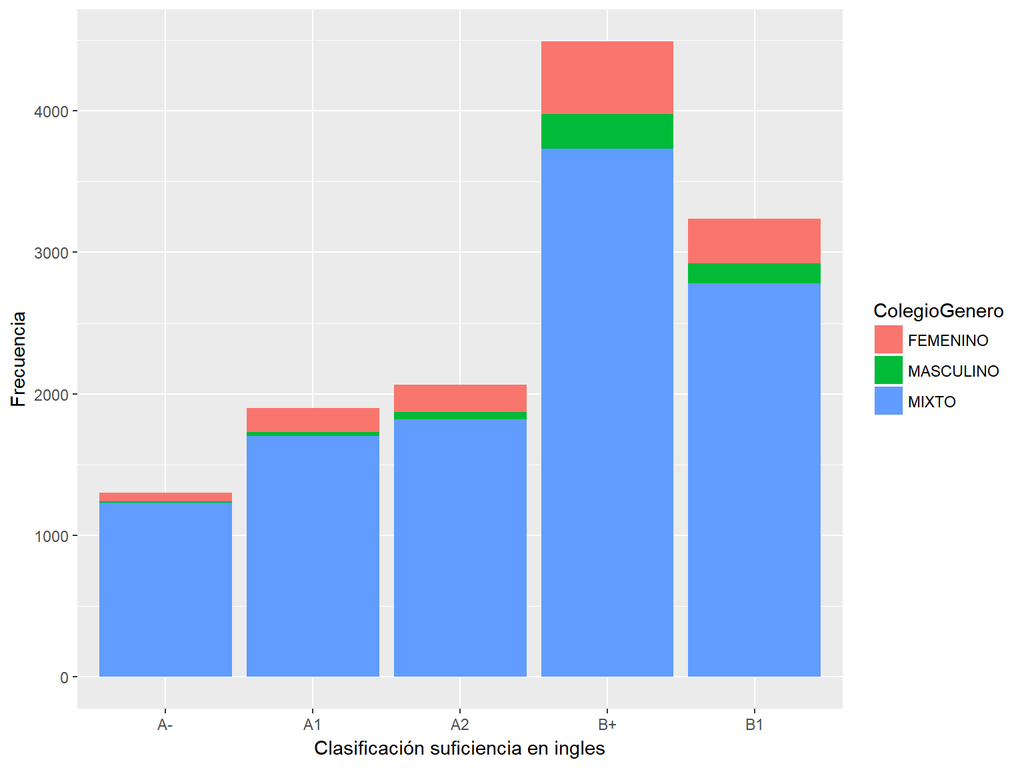

```r
g <- ggplot(data = icfes17, aes(x = InglesPe))
g <- g + geom_bar(aes(fill = ColegioGenero))
g <- g + xlab("Clasificación suficiencia en ingles") + ylab("Frecuencia")
g
```

# Histogramas (`geom_histogram`)

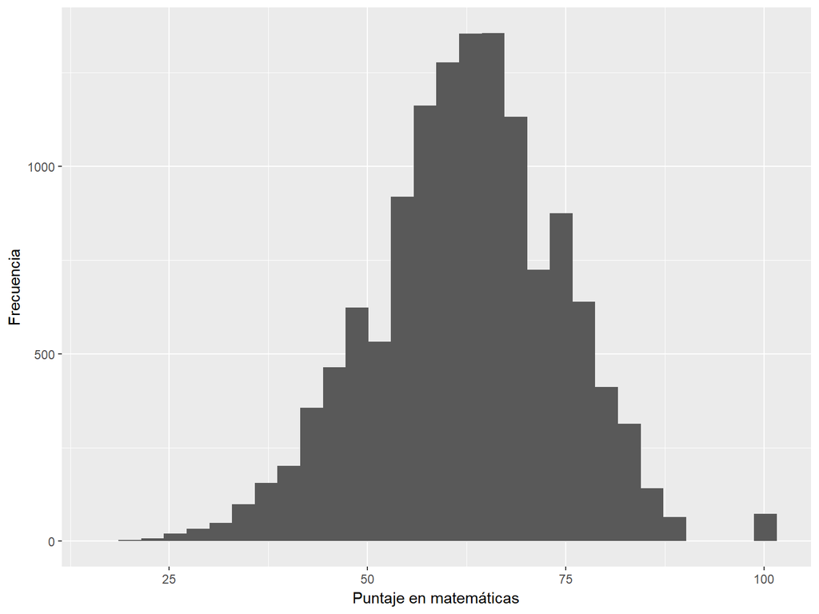

```r
g <- ggplot(data = icfes17, aes(x = MatematicasPu))
g <- g + geom_histogram()
g <- g + xlab("Puntaje en matemáticas") + ylab("Frecuencia")
g
```

Resultados de puntuación en matemáticas por estrato

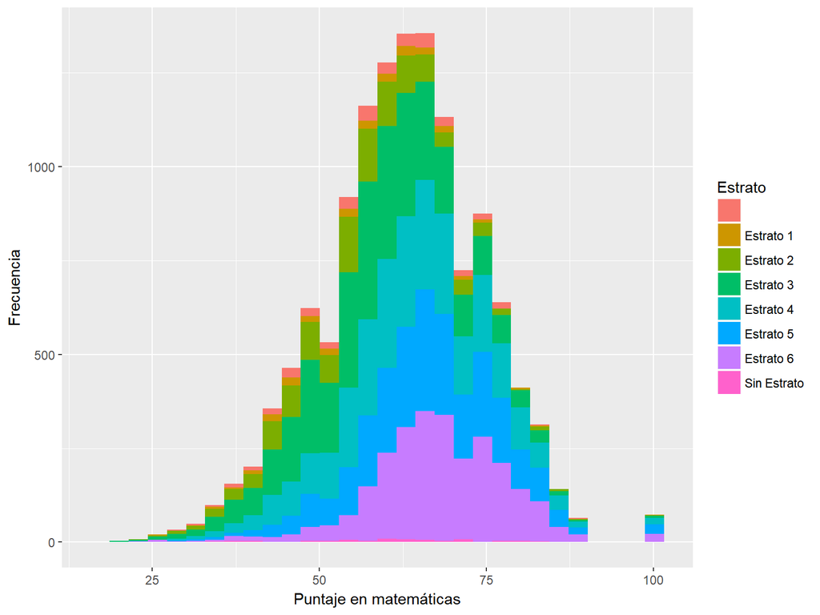

```r
g <- ggplot(data = icfes17, aes(x = MatematicasPu))
g <- g + geom_histogram(aes(fill = Estrato))
g <- g + xlab("Puntaje en matemáticas") + ylab("Frecuencia")
g
```

# Densidad (`geom_density`)

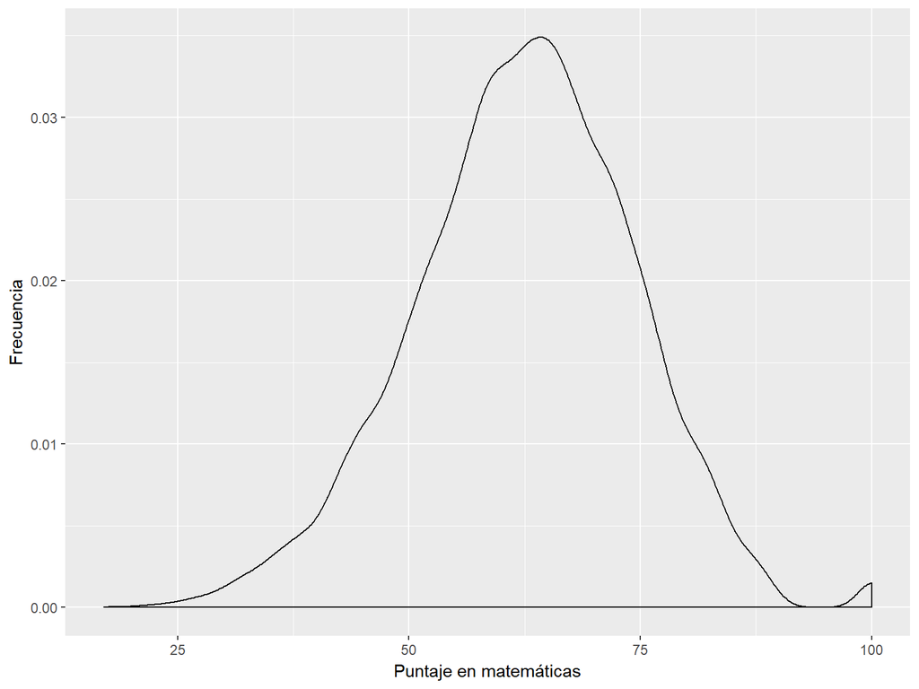

```r
g <- ggplot(data = icfes17, aes(x = MatematicasPu))
g <- g + geom_density()
g <- g + xlab("Puntaje en matemáticas") + ylab("Frecuencia")
g
```

Resultados de puntuación en matemáticas por estrato

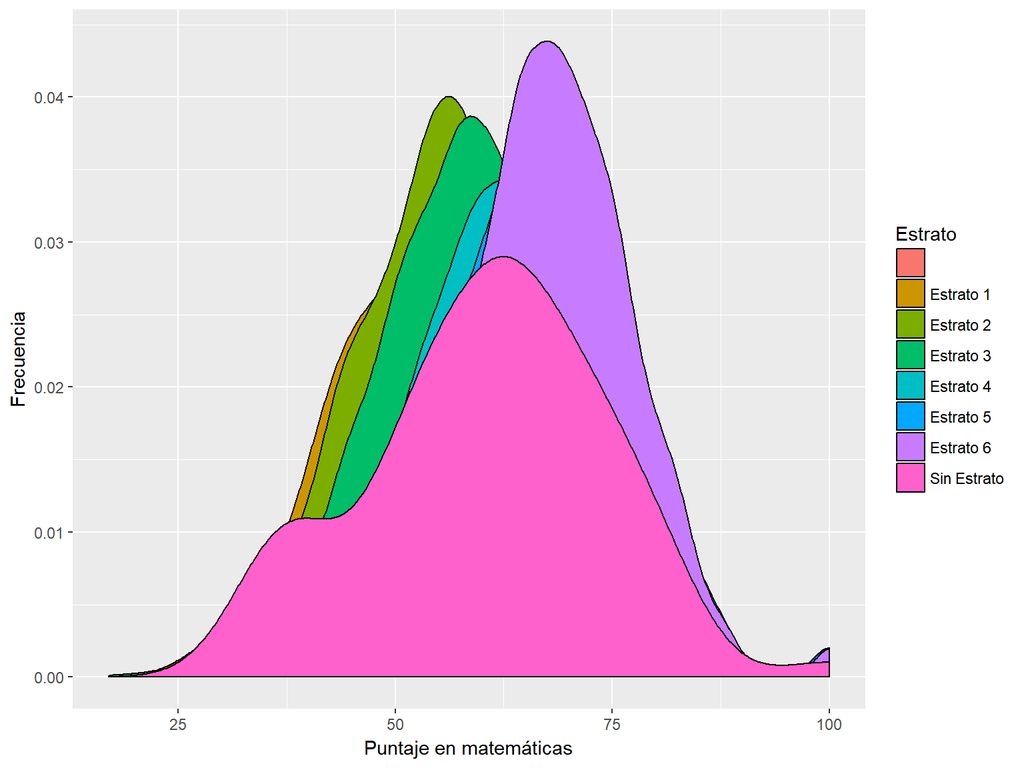

```r
g <- ggplot(data = icfes17, aes(x = MatematicasPu))
g <- g + geom_density(aes(fill = Estrato))
g <- g + xlab("Puntaje en matemáticas") + ylab("Frecuencia")
g
```

# Boxplot (`geom_boxplot`)

Resultados de matemáticas por estrato

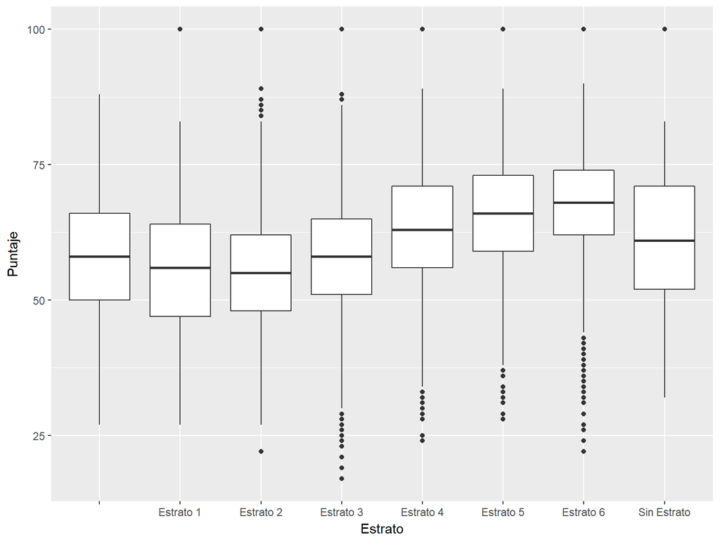

```r
g <- ggplot(data = icfes17, aes(x = Estrato, y = MatematicasPu))
g <- g + geom_boxplot()
g <- g + xlab("Estrato") + ylab("Puntaje")
g
```

Resultados de matemáticas por estrato y área de ubicación del colegio

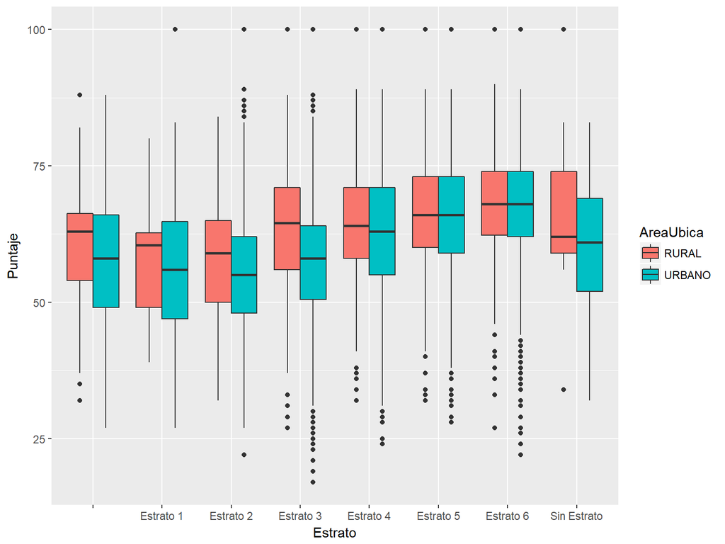

```r
g <- ggplot(data = icfes17, aes(x = Estrato, y = MatematicasPu))
g <- g + geom_boxplot(aes(fill = AreaUbica))
g <- g + xlab("Estrato") + ylab("Puntaje")
g
```

Resultados de matemáticas por estrato y categorización de colegio (bilingüe o no)

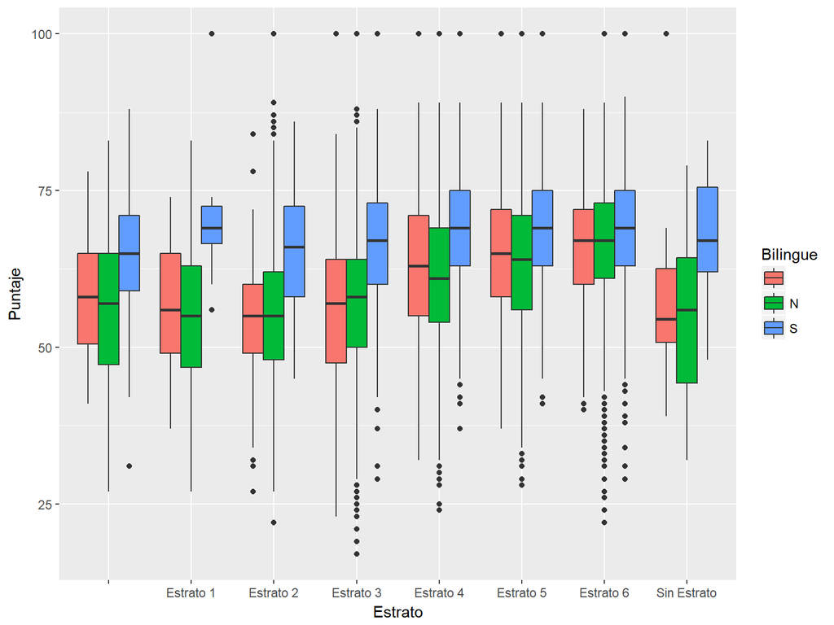

```r
g <- ggplot(data = icfes17, aes(x = Estrato, y = MatematicasPu))
g <- g + geom_boxplot(aes(fill = Bilingue))
g <- g + xlab("Estrato") + ylab("Puntaje")
g
```

# Diagrama de dispersión (`geom_point` o `geom_jitter`)

Ciencias naturales vs matemáticas

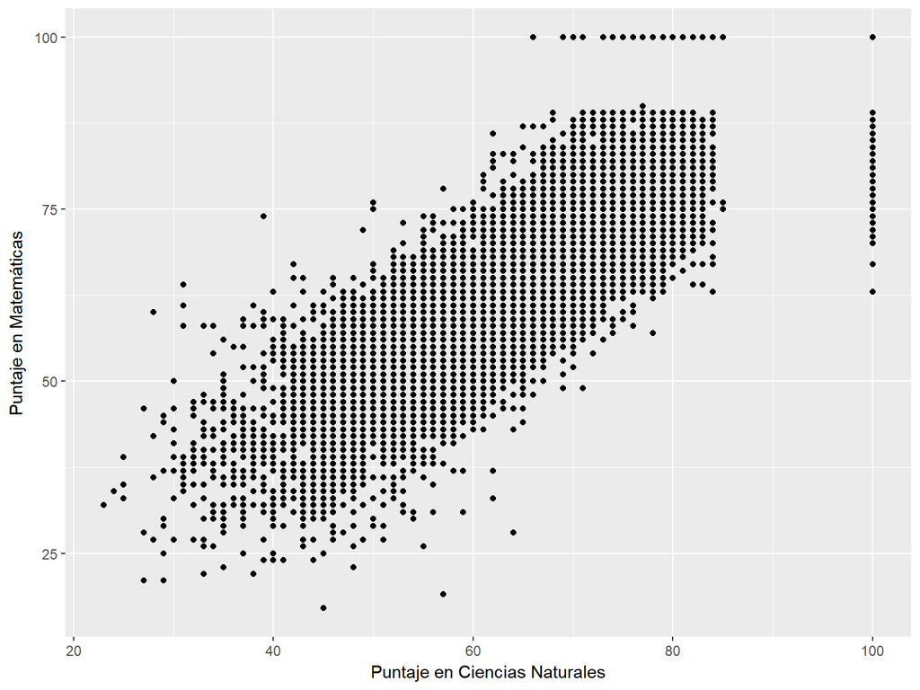

```r
g <- ggplot(data = icfes17, aes(x = CNaturalesPu, y = MatematicasPu))
g <- g + geom_point()
g <- g + xlab("Puntaje en Ciencias Naturales") + ylab("Puntaje en Matemáticas")
g
```

Ciencias naturales vs matemáticas por estrato

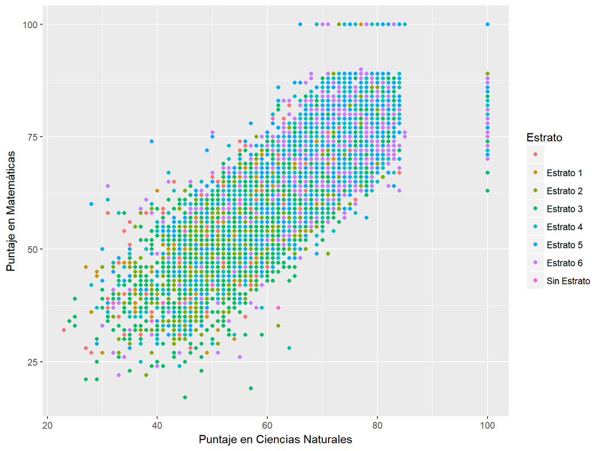

```r
g <- ggplot(data = icfes17, aes(x = CNaturalesPu, y = MatematicasPu))
g <- g + geom_point(aes(colour = Estrato))
g <- g + xlab("Puntaje en Ciencias Naturales") + ylab("Puntaje en Matemáticas")
g
```

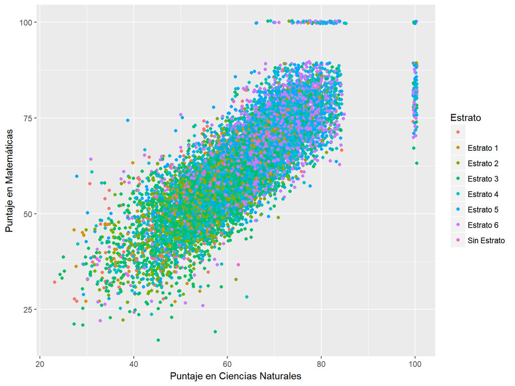

```r
g <- ggplot(data = icfes17, aes(x = CNaturalesPu, y = MatematicasPu))
g <- g + geom_jitter(aes(colour = Estrato))
g <- g + xlab("Puntaje en Ciencias Naturales") + ylab("Puntaje en Matemáticas")
g
```